# Práctica 02

# 1 Instrucciones

### Enunciado

En esta practica se ofrecen datos (no reales) de nº de visitantes y gasto medio por visitante en los **principales destinos turísticos** estivales de la Comunidad Valenciana. Los datos están desagregados por el origen de los visitantes.

### Tareas a realizar

1. Completar la hoja DATOS con la función SUMA y PROMEDIO y los operadores matemáticos correspondientes
2. En la hoja TABLAS resumir los datos, crear tablas de índices y porcentajes
3. Crear una hoja GRÁFICO, crear los gráficos que se indiquen en clase

## ¿Qué aprenderemos?

**¿Qué aprenderemos?**

Aprender y practicar los siguientes aspectos relativos al manejo de Excel:

- Copiar/pegar/pegado especial
- Insertar/suprimir filas/columnas/hojas
- **Referencias relativas**
- **Formato** celdas/número
- Pegar formato
- Funciones SUMA y SUMAPROMEDIO
- **Gráficos**

Crear tablas de porcentajes e índices relativos a datos absolutos como herramienta de interpretación de los datos

Aprender a diseñar aquellos gráficos y tablas que ilustren las ideas que se desean mostrar.

Aprender a confeccionar y a interpretar tablas de porcentajes e índices.

# 2 Resolución

## Tarea 1

#### Tarea 1: enunciado

1. Completar la hoja DATOS con la función SUMA y PROMEDIO y los operadores matemáticos correspondientes

**Tarea 1: datos, solución (y estrategía)**

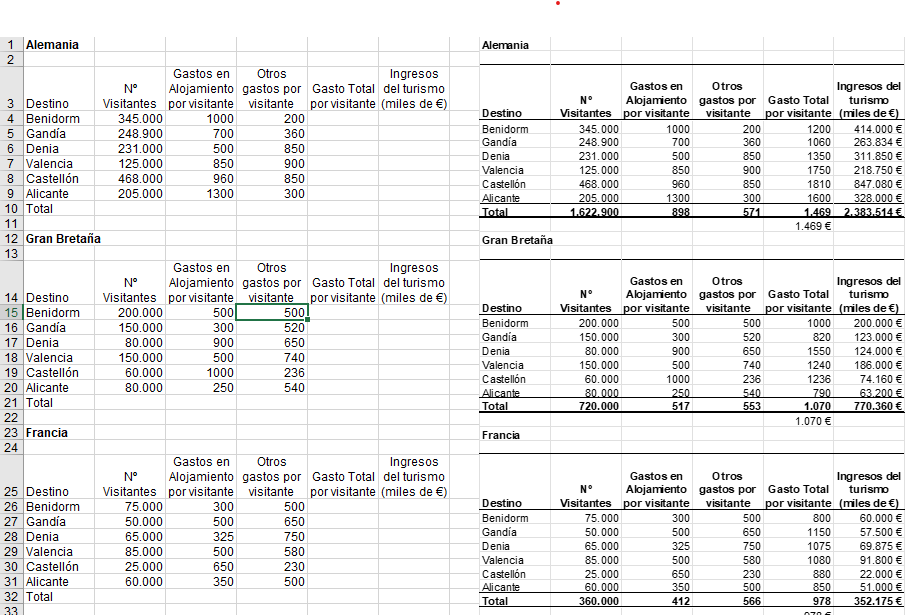

**Estrategia**

1. Rellenar las 2 últimas columnas (Gasto Total por visitante e Ingresos totales)
2. Rellenar la última fila (Totales)  
   Cuidado!!! En la última fila “habrán 2 tipos” de celdas, en unas tendremos que usar la función `SUMA()` y en otras usaremos la función `SUMAPRODUCTO()`. Lo vemos
3. Dar formato a la tabla

## Tarea 2

#### Tarea 2: enunciado

2. En la hoja TABLA resumir los datos, crear tablas de índices y porcentajes

**Tarea 2: datos, solución (y estrategía)**

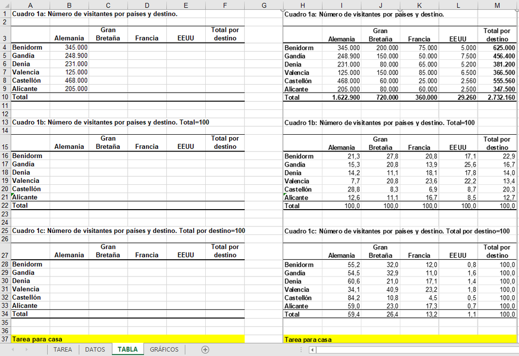

**Estrategia**

Para completar las tablas 1a, 1b y 1c hay que:

- **Tabla 1a**:
  - hay que copiar los datos originales de visitantes por países y destinos (mejor si lo hacemos por referencia)
  - después rellenar la columna de totales (por destino)
  - rellenar la fila ultima de totales
  - dar formato

Una vez tenemos la Tabla 1a podemos continuar.

- **Tabla 1b**:
  - hay que calcular porcentajes; concretamente hay que calcular el % de los visitantes de cada nacionalidad o país (Francia, Alemania etc…) que van a cada destino turístico (Benidorm, Gandía, …). Por ejemplo, si te fijas, si nos centrarmos en los turistas alemanes, el 14,2% de los alemanes van a Denia
- **Tabla 1c**:
  - También calculamos porcentajes, pero ahora se trata de calcular para cada destino turístico (Benidorm, Gandía, …) el % de visitantes de cada nacionalidad

## Tarea 3

#### Tarea 3: enunciado

3. Crear una hoja GRÁFICO, crear los gráficos que se indiquen en clase

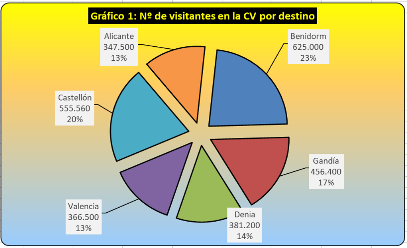

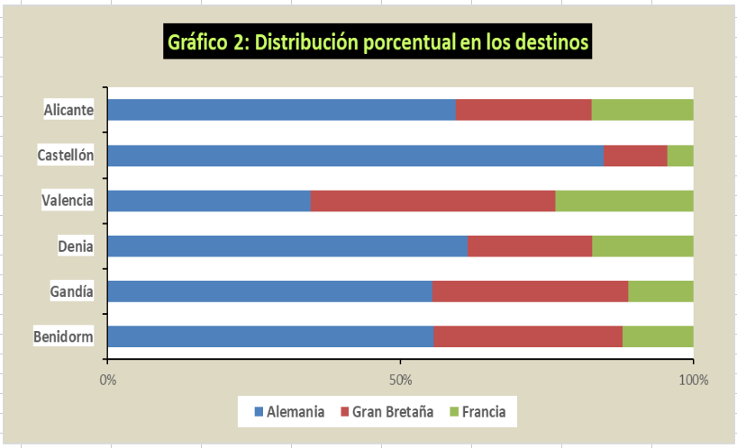

Tres formas de **crear gráficos**:

- Seleccionar los datos y pulsar **F11** (Excel nos hará el gráfico automáticamente y lo colocará en una nueva hoja)
- Seleccionar los datos y pulsar **ALT + F1** (hará el gráfico automáticamente pero o situara en la hoja de datos)
- Seleccionar los datos y clicar en la pestaña “Insertar Gráfico”

Después “solo” queda dar ajustar y dar formato al gráfico

**Partes de un gráfico**:

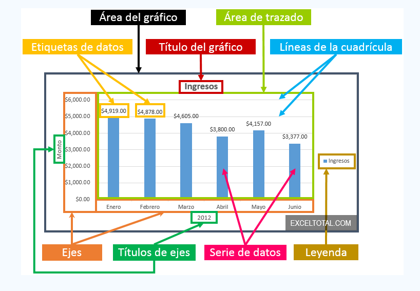

Proveniente de [aquí](https://exceltotal.com/partes-de-un-grafico-en-excel-2013/)

Proveniente de [aquí](https://exceltotal.com/partes-de-un-grafico-en-excel-2013/)

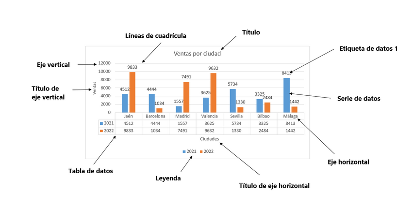

Proveniente de [aquí](https://www.plantillaspyme.com/blog-pymes/excel/partes-de-un-grafico-excel)

Un vídeo explicativo [aquí](https://www.youtube.com/watch?v=uFLRUC6gbnU)

**“Formateo” de un gráfico**

- Si quieres cambiar el tipo de gráfico: Clic derecho en el gráfico → Cambiar tipo de gráfico
- Si quieres cambiar rápidamente el estilo de tu gráfico usa los estilos predefinidos, para ello: Seleccionar el gráfico → Pestaña Diseño y elije el estilo
- Si quieres cambiar la paleta de colores del gráfico: Diseño → Cambiar colores → Seleccionar paleta

**Elementos concretos del gráfico**

- Si quieres agregar elementos e tu gráfico: Diseño → Agregar elemento de gráfico
- Para dar formato a un elemento concreto de tu gráfico, seleccionalo con doble click
- Si quieres eliminar un elemento de tu gráfico, pincha en SUPR